# Global Interpretation Methods

In-class exercise 09-2

# Goal

Apply what you have learned about global interpretation methods.

# Prerequisites

We need the following libraries:

```r
library('mlr3verse')
library('iml')
library('gridExtra')
library('ggpubr')
set.seed(100)
```

# Data

### German Credit

```r
task = tsk("german_credit")
task$select(cols = c("age", "amount", "duration", "credit_history", "employment_duration", "personal_status_sex", "purpose"))
```

# 1 Categorical ALE

## 1.1 Fit a Random Forest

Fit a random forest with `mlr3` on some training data to predict the risk.

### Solution:

**Click me:**

```r
split = partition(task)
learner = lrn("classif.ranger", predict_type = "prob")$train(task, row_ids = split$train)
```

## 1.2 Compute PDP of personal_status_sex

Since the decision of whether a person gets a loan can have serious implications on the person’s life, banks are subordinate to regulations and must disclose the underlying mechanism of their used model to authorities. Since looking on the single trees is not feasible to uncover the internals of a random forest, (model-agnostic) interpretation methods should help to unfold the underlying mechanisms and to explain specific decisions. Since the regulations require that the model does not discriminate against certain groups, you want to evaluate the feature effect of `personal_status_sex` of the fitted forest model. Compute and visualize the PDP of `personal_status_sex` using test data and interpret the results.

**Hint 1:**

To make the x-axis labels more legible, you can append the following code to the `plot()` function:

```r
plot (...) +
  theme(axis.text.x = element_text(angle = 50, hjust=1))
```

### Solution:

**Click me:**

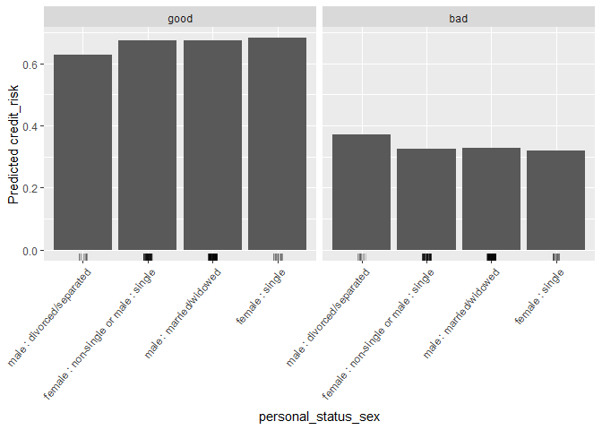

```r
# Predictor:
pred = Predictor$new(learner, data = task$data(rows = split$test), y = "credit_risk")

# Compute PDP:
plot(FeatureEffect$new(predictor = pred,
                       feature = "personal_status_sex",
                       method = "pdp")) +
  theme(axis.text.x = element_text(angle = 50, hjust=1))
```

All customers, regardless of their personal status and gender, have on average a high probability of being a low (good) risk for the bank. The average marginal prediction for divorced or separated male customers reveals a slightly higher risk for this group.

## 1.3 Analyse the corresponding ALE plot

Because the ALE models accumulated effects in a specific direction, the feature values must have an order by definition. However, there is no natural order to categorical/nominal features like `personal_status_sex`. In order to derive an artificial order, Molnar 2022 (Chapter 8.2)[^1] proposes to order the categories of the features of interest $x_s$ according to their similarity based on other/remaining features $x_{-S}$. Take a look at the corresponding ALE plot and compare the results to the PDP.

### Solution:

**Click me:**

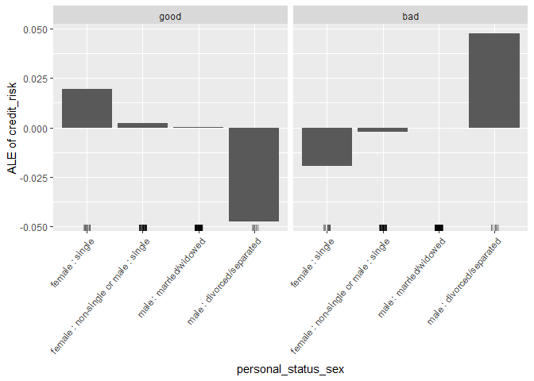

```r
plot(FeatureEffect$new(predictor = pred,
                       feature = "personal_status_sex",
                       method = "ale")) +
  theme(axis.text.x = element_text(angle = 50, hjust=1))
```

# 2 PFI

## 2.1 A synthetic example

Download the `extrapolation.csv` dataset and remove the column that only contains the row indices (`X`). Fit a linear regression model with `mLr3` to some training data. Do not look at the model’s coefficients or perform an exploratory analysis of the data yet. Assess the MSE of the model on test data.

### Solution:

**Click me:**

```r
# load data and remove column "X"
df = read.csv("../data/extrapolation.csv")
df <- df[ , -which(names(df) == "X")]

# create task and split in into train and test data
task = as_task_regr(x = df, target = "y")
split = partition(task)

#learn and predict
lm = lrn("regr.lm")
lm$train(task, row_ids = split$train)
pred_lm = Predictor$new(lm, data = task$data(rows = split$test), y = "y")
preds = pred_lm$predict(task$data(rows = split$test))

# MSE
mse <- mean((task$data(rows = split$test)$y - preds$predict.model..newdata...newdata.) ^ 2)
print(paste("MSE:", round(mse,4)))
```

```
## [1] "MSE: 0.009"
```

## 2.2 Calculate and interpret PFI values

Apply Permutation Feature Importance to the model (on test data) and plot the results.

### Solution:

**Click me:**

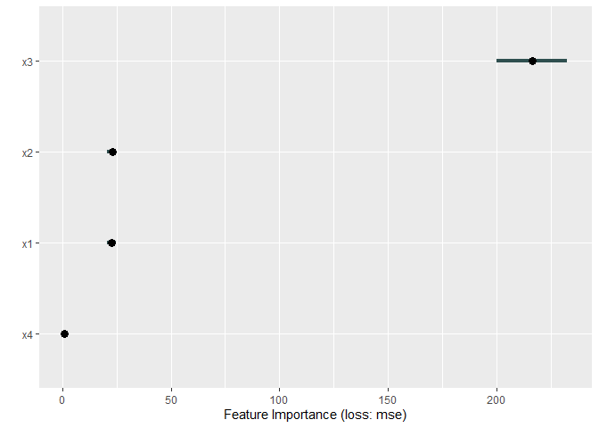

```r
importance = FeatureImp$new(pred_lm, loss = "mse", n.repetitions = 10)
plot(importance)
```

$X_3$ is the most important feature, with $X_1$ and $X_2$ sharing the second place. PFI considers $X_4$ to be irrelevant.

## 2.3 Exploratory analysis

Perform an exploratory analysis of the data (correlation structure between features and with $y$) and print the model’s coefficients and intercept. What additional insight into the relationship of the features with $y$ do we gain by looking at the correlation structure of the covariates in addition to the PFI (assuming that all dependencies are linear)?

### Solution:

**Click me:**

```r
cor(task$data(rows = split$test))
```

```
##             y          x1          x2          x3           x4
## y  1.00000000  0.04295207  0.04254775 0.995491225  0.010055298
## x1 0.04295207  1.00000000  0.99994280 0.040784544 -0.077401274
## x2 0.04254775  0.99994280  1.00000000 0.040220635 -0.077765057
## x3 0.99549123  0.04078454  0.04022064 1.000000000  0.006898365
## x4 0.01005530 -0.07740127 -0.07776506 0.006898365  1.000000000
```

```r
lm$model$coefficients
```

```
##  (Intercept)           x1           x2           x3           x4
##  0.001216415  0.328582933 -0.331450967  1.009419690  0.004267062
```

If we know the dependency structure of the covariates we can infer whether or not the PFI value is nonzero due to a dependency with the covariates or not. In our example we now know that $x_3$ is independent of its covariates, so we hypothesize that $x_3$ is actually dependent with $y$. Since $x_1, x_2$ are dependent, for those variables we cannot infer anything about the dependency with $y$ with the covariates dependency structure and PFI alone.

# Summary

In this exercise, we analyzed an example of ALE on a categorical target and deepened our understanding of PFI.

[^1]: https://christophm.github.io/interpretable-ml-book/ale.html